# Assembly Quality Metrics - Quast Results

Håkon Kaspersen

12.06.2019

```r
library(dplyr)
library(ggplot2)
library(tidyr)
library(cowplot)
library(scales)
```

```r
path <- "../data/quast/"

file_names <- function(filepath) {
  files <- list.files(path = filepath, pattern = ".tsv")
  return(files)
}

create_df <- function(df) {
  df <- df %>%
    dplyr::rename(ctg_0_bp = X..contigs.....0.bp.,
           ctg_1000_bp = X..contigs.....1000.bp.,
           ctg_5000_bp = X..contigs.....5000.bp.,
           ctg_10000_bp = X..contigs.....10000.bp.,
           ctg_25000_bp = X..contigs.....25000.bp.,
           ctg_50000_bp = X..contigs.....50000.bp.,
           tot_len_0_bp = Total.length.....0.bp.,
           tot_len_1000_bp = Total.length.....1000.bp.,
           tot_len_5000_bp = Total.length.....5000.bp.,
           tot_len_10000_bp = Total.length.....10000.bp.,
           tot_len_25000_bp = Total.length.....25000.bp.,
           tot_len_50000_bp = Total.length.....50000.bp.,
           no_of_contigs = X..contigs,
           no_of_misassemblies = X..misassemblies,
           no_of_misassembled_ctg = X..misassembled.contigs,
           no_of_local_misassemblies = X..local.misassemblies,
           unaligned_contigs = X..unaligned.contigs,
           N_per_100kbp = X..N.s.per.100.kbp,
           mismatches_per_100kbp = X..mismatches.per.100.kbp,
           indels_per_100kbp = X..indels.per.100.kbp,
           genes = X..genes,
           GC = GC....,
           duplication_ratio = Duplication.ratio,
           largest_contig = Largest.contig)
  return(df)
}
```

```r
files <- file_names(path)

data_list <- lapply(files,
                    FUN = function(file) {
                      read.delim(paste0(path, "/", file),
                                 sep = "\t",
                                 header = TRUE,
                                 stringsAsFactors = FALSE)
                    })

data_list <- lapply(data_list, function(df) mutate_all(df, as.character))

names(data_list) <- files

df <- bind_rows(data_list)

df_clean <- create_df(df) %>%
  filter(grepl("broken", Assembly) == FALSE) %>%
  filter(Assembly %not_in% c("51-2016-02-486_S31_pilon_spades",
                             "68-2016-17-565_S45_pilon_spades",
                             "52-2016-02-732_S43_pilon_spades",
                             "50-2016-02-428_S19_pilon_spades")) %>%
  mutate(ref = Assembly %>%
           gsub("_pilon_spades", "", .)) %>%
  left_join(id_data, by = "ref") %>%
  left_join(isolate_data[c("id","sequencer")], by = "id")

metrics <- df_clean %>%
  select(id,
         no_of_contigs,
         largest_contig,
         GC,
         N50,
         NG50,
         L50,
         LG50,
         no_of_misassemblies,
         duplication_ratio,
         genes) %>%
  mutate_at(vars(no_of_contigs,
                 largest_contig,
                 N50),
            funs(as.numeric))

metrics
```

| id | no_of_contigs | largest_contig | GC | N50 | NG50 | L50 | LG50 | no_of_misassemblies | duplication_ratio | genes |
| --- | --- | --- | --- | --- | --- | --- | --- | --- | --- | --- |
| 2016-02-692-2-S | 84 | 419144 | 50.5 | 189285 | 189041 | 10 | 11 | 165 | 1.005 | 3351 + 131 part |
| 2016-02-363-2-S | 124 | 296583 | 50.62 | 99151 | 89068 | 15 | 18 | 118 | 1.003 | 3618 + 134 part |
| 2016-17-363-1-S | 94 | 273691 | 50.62 | 117784 | 105742 | 14 | 18 | 112 | 1.003 | 3537 + 137 part |
| 2016-02-408-2-S | 125 | 444310 | 50.73 | 137752 | 125883 | 10 | 13 | 120 | 1.005 | 3574 + 140 part |
| 2016-02-351-2-S | 125 | 444310 | 50.73 | 137939 | 126321 | 10 | 12 | 121 | 1.005 | 3569 + 139 part |
| 2016-17-388-1-T | 61 | 338266 | 50.51 | 161994 | 149307 | 11 | 13 | 137 | 1.005 | 3579 + 139 part |
| 2016-02-739-2-S | 110 | 627741 | 50.55 | 395134 | 395134 | 6 | 6 | 182 | 1.003 | 3338 + 153 part |
| 2009-01-4618-2-T | 65 | 415783 | 50.56 | 184733 | 178362 | 9 | 11 | 120 | 1.003 | 3664 + 121 part |
| 2016-02-546-2-S | 93 | 277888 | 50.66 | 111619 | 99008 | 14 | 18 | 114 | 1.003 | 3560 + 133 part |
| 2016-02-411-2-S | 79 | 408465 | 50.75 | 118260 | 90804 | 13 | 18 | 108 | 1.003 | 3554 + 120 part |

[output cut: 271 more lines]

```r
metrics2 <- metrics %>%
  left_join(isolate_data, by = "id")

embed_data <- function(x = mtcars,
                       filename = "file.csv",
                       label= "Get data") {

  # Create encoded Base64 datastream
  encode_data <- function(x){
    write.csv2(x, "./file.csv")
    enc= sprintf('data:text/csv;base64,%s',
                 openssl::base64_encode(
                   paste0(
                     readLines("./file.csv"),
                     collapse="\n")
                   )
                 )
    unlink("./file.csv")
    return(enc)
  }

  # String result ready to be placed in rmarkdown
  paste0("<a download='", filename, "' href=", encode_data(x), ">", label, "</a>")

}
```

Get data

# 1 Mean metrics

```r
metrics3 <- filter(metrics2, id != "2014-01-1741-1-S")

print(paste0("Mean number of contigs: ", round(mean(metrics3$no_of_contigs), 1)))
```

```
## [1] "Mean number of contigs: 93.8"
```

```r
print(paste0("Mean size of largest contigs: ", round(mean(metrics3$largest_contig), 1)))
```

```
## [1] "Mean size of largest contigs: 450491.3"
```

```r
print(paste0("Mean N50: ", round(mean(metrics3$N50), 1)))
```

```
## [1] "Mean N50: 170631.3"
```

```r
print(paste0("Mean NG50: ", round(mean(as.numeric(metrics3$NG50)), 1)))
```

```
## [1] "Mean NG50: 151655.9"
```

# 2 Summarised assembly stats

## 2.1 Summary stats per animal species

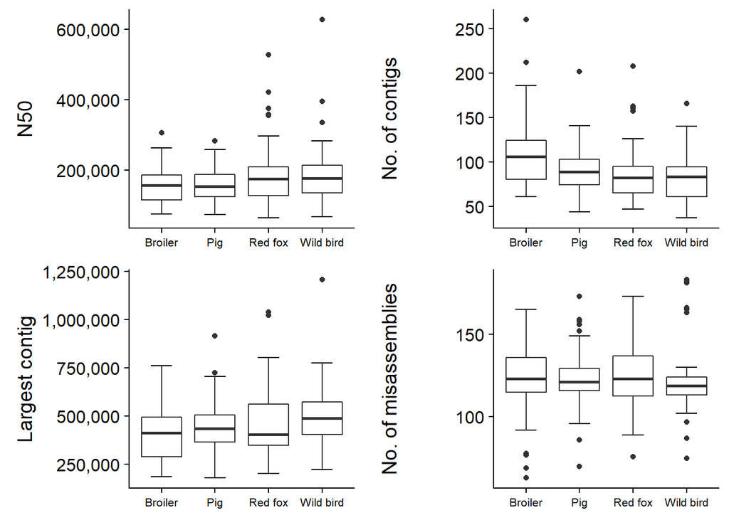

```r
p1 <- ggplot(metrics3, aes(species, N50)) +
  stat_boxplot(geom = "errorbar", width = 0.4) +
  geom_boxplot() +
  scale_y_continuous(labels = comma) +
  theme(axis.title.x = element_blank(),
        axis.text.x = element_text(size = 8))

p2 <- ggplot(metrics3, aes(species, no_of_contigs)) +
  stat_boxplot(geom = "errorbar", width = 0.4) +
  geom_boxplot() +
  labs(y = "No. of contigs") +
  theme(axis.title.x = element_blank(),
        axis.text.x = element_text(size = 8))

p3 <- ggplot(metrics3, aes(species, largest_contig)) +
  stat_boxplot(geom = "errorbar", width = 0.4) +
  geom_boxplot() +
  labs(y = "Largest contig") +
  scale_y_continuous(labels = comma) +
  theme(axis.title.x = element_blank(),
        axis.text.x = element_text(size = 8))

p4 <- ggplot(metrics3, aes(species, as.numeric(no_of_misassemblies))) +
  stat_boxplot(geom = "errorbar", width = 0.4) +
  geom_boxplot() +
  labs(y = "No. of misassemblies") +
  scale_y_continuous(labels = comma) +
  theme(axis.title.x = element_blank(),
        axis.text.x = element_text(size = 8))

plot_grid(p1, p2, p3, p4, ncol = 2, nrow = 2, align = "v")
```

## 2.2 Summary stats per sequencing method

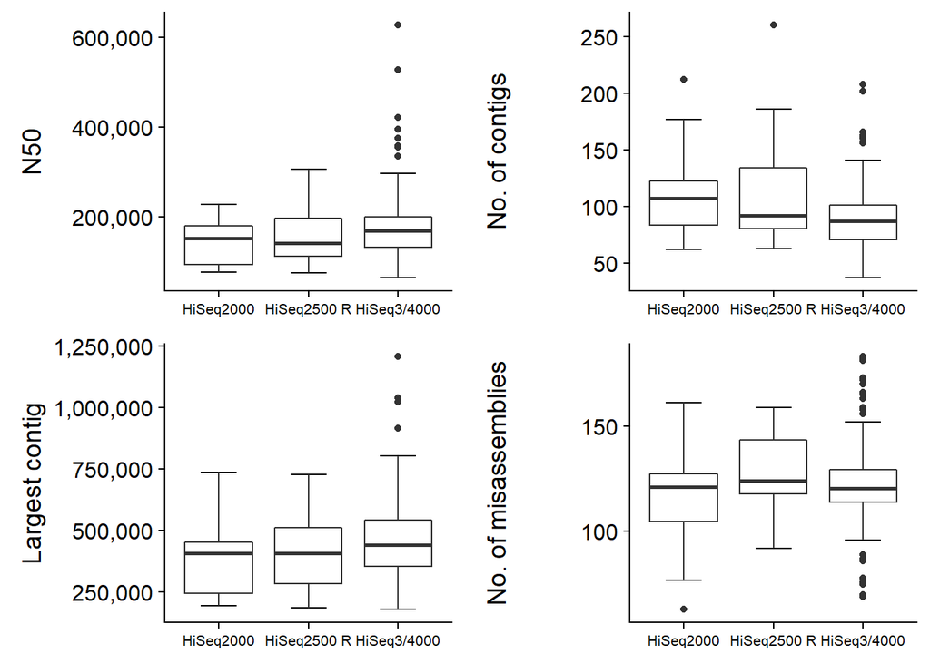

```r
p5 <- ggplot(metrics3, aes(sequencer, N50)) +
  stat_boxplot(geom = "errorbar", width = 0.4) +
  geom_boxplot() +
  scale_y_continuous(labels = comma) +
  theme(axis.title.x = element_blank(),
        axis.text.x = element_text(size = 8))

p6 <- ggplot(metrics3, aes(sequencer, no_of_contigs)) +
  stat_boxplot(geom = "errorbar", width = 0.4) +
  geom_boxplot() +
  labs(y = "No. of contigs") +
  theme(axis.title.x = element_blank(),
        axis.text.x = element_text(size = 8))

p7 <- ggplot(metrics3, aes(sequencer, largest_contig)) +
  stat_boxplot(geom = "errorbar", width = 0.4) +
  geom_boxplot() +
  labs(y = "Largest contig") +
  scale_y_continuous(labels = comma) +
  theme(axis.title.x = element_blank(),
        axis.text.x = element_text(size = 8))

p8 <- ggplot(metrics3, aes(sequencer, as.numeric(no_of_misassemblies))) +
  stat_boxplot(geom = "errorbar", width = 0.4) +
  geom_boxplot() +
  labs(y = "No. of misassemblies") +
  scale_y_continuous(labels = comma) +
  theme(axis.title.x = element_blank(),
        axis.text.x = element_text(size = 8))

plot_grid(p5, p6, p7, p8, ncol = 2, nrow = 2, align = "v")
```